# Regression Analysis of IMDB 5000 Movies Datasets

Purpose: By doing a regresson analysis, we want to know: 1) Among the 27 variables given, which of them are critical in telling the IMDB rating of a movie. 2) Is there any correlation between genre & IMDB raging,face number in poster & IMDB rating,director name & IMDB rating and duration & IMDB rating. 3) Predict the IMDB Score using our model

```r
m<- read.csv('movie_metadata.csv')
```

## Step 1: Data Collection

This data set was found from Kaggle. The author scraped 5000+ movies from IMDB website using a Python library called “scrapy” and obtain all needed 28 variables for 5043 movies and 4906 posters (998MB), spanning across 100 years in 66 countries. There are 2399 unique director names, and thousands of actors/actresses. Below are the 28 variables: “movie_title” “color” “num_critic_for_reviews” “movie_facebook_likes” “duration” “director_name” “director_facebook_likes” “actor_3_name” “actor_3_facebook_likes” “actor_2_name” “actor_2_facebook_likes” “actor_1_name” “actor_1_facebook_likes” “gross” “genres” “num_voted_users” “cast_total_facebook_likes” “facenumber_in_poster” “plot_keywords” “movie_imdb_link” “num_user_for_reviews” “language” “country” “content_rating” “budget” “title_year” “imdb_score” “aspect_ratio”

This dataset is a proof of concept. It can be used for experimental and learning purpose.For comprehensive movie analysis and accurate movie ratings prediction, 28 attributes from 5000 movies might not be enough. A decent dataset could contain hundreds of attributes from 50K or more movies, and requires tons of feature engineering.

## Step 2 : Data cleaning and exploration

Assign the first word of genres as the genre of each movie:(genres been split into words in Excel):

```r
# remove columns X-X.8
which(colnames(m)=='genres')
```

```
[1] 10
```

```r
which(colnames(m)=='X.8')
```

```
[1] 19
```

```r
m<-m[,-c(11:19)]
```

Only keep movie data for USA, bacause the “budget” variable was not all converted to US dollars, which might cause a problem in later analysis. If we want to convert all budgets into US dollarts, we have to take in to consideration for inflation as well. This might make the problem more complicated. Therefore, for pratice purpose, we decided to only study data for movies of USA.

```r
movie.usa<-m[which(m[,'country']=='USA'),]
```

Double check:

```r
movie.usa$country
```

[output not shown]

[output cut: 35 more lines]

```r
summary(movie.usa$language)
```

```
           Aboriginal     Arabic    Aramaic    Bosnian  Cantonese    Chinese      Czech
        10          0          0          1          1          1          0          0
    Danish       Dari      Dutch   Dzongkha    English   Filipino     French     German
         0          1          0          0       3779          1          0          0
     Greek     Hebrew      Hindi  Hungarian  Icelandic Indonesian    Italian   Japanese
         0          1          1          0          0          0          0          1
   Kannada     Kazakh     Korean   Mandarin       Maya  Mongolian       None  Norwegian
         0          0          0          0          1          0          1          0
   Panjabi    Persian     Polish Portuguese   Romanian    Russian  Slovenian    Spanish
         0          0          0          0          0          0          0          7
   Swahili    Swedish      Tamil     Telugu       Thai       Urdu Vietnamese       Zulu
         0          0          0          0          0          0          1          0
```

```r
movie.usa<-movie.usa[, -which(names(movie.usa)=='language')]
```

Remove ‘movie_imdb_link’ column since it’s not useful for our analysis and store the rest od the data as ‘movie’.

```r
movie.df= data.frame(movie.usa)
mm<-movie.df[, -which(names(movie.df)=='movie_imdb_link')]
```

```r
str(mm)
```

```
'data.frame':   3807 obs. of  26 variables:
 $ color                    : Factor w/ 3 levels ""," Black and White",..: 3 3 3 3 3 3 3 3 3 3 ...
 $ director_name            : Factor w/ 2399 levels "","\xcc\xe4mile Gaudreault",..: 926 799 379 106 2030 1652 1225 2394 284 799 ...
 $ num_critic_for_reviews   : int  723 302 813 462 392 324 635 673 434 313 ...
 $ duration                 : int  178 169 164 132 156 100 141 183 169 151 ...
 $ director_facebook_likes  : int  0 563 22000 475 0 15 0 0 0 563 ...
 $ actor_3_facebook_likes   : int  855 1000 23000 530 4000 284 19000 2000 903 1000 ...
 $ actor_2_name             : Factor w/ 3033 levels "","50 Cent","A. Michael Baldwin",..: 1408 2218 534 2549 1228 801 2440 1704 1911 2218 ...
 $ actor_1_facebook_likes   : int  1000 40000 27000 640 24000 799 26000 15000 18000 40000 ...
 $ gross                    : int  760505847 309404152 448130642 73058679 336530303 200807262 458991599 330249062 200069408 423032628 ...
 $ genres                   : Factor w/ 21 levels "Action","Adventure",..: 1 1 1 1 1 2 1 1 1 1 ...
 $ actor_1_name             : Factor w/ 2098 levels "","\xcc\xd2lafur Darri \xcc\xd2lafsson",..: 303 982 1968 441 786 221 337 740 1104 982 ...
 $ movie_title              : Factor w/ 4917 levels "[Rec] 2\xe5\xca",..: 397 2731 3707 1960 3289 3459 398 460 3416 2732 ...
 $ num_voted_users          : int  886204 471220 1144337 212204 383056 294810 462669 371639 240396 522040 ...
 $ cast_total_facebook_likes: int  4834 48350 106759 1873 46055 2036 92000 24450 29991 48486 ...
 $ actor_3_name             : Factor w/ 3522 levels "","\xcc\xd2scar Jaenada",..: 3442 1393 1769 2714 1969 2162 3018 57 1134 1393 ...
 $ facenumber_in_poster     : int  0 0 0 1 0 1 4 0 0 2 ...
 $ plot_keywords            : Factor w/ 4761 levels "","10 year old|dog|florida|girl|supermarket",..: 1320 4283 3484 651 4745 29 1142 1564 3312 2188 ...
 $ num_user_for_reviews     : int  3054 1238 2701 738 1902 387 1117 3018 2367 1832 ...
 $ country                  : Factor w/ 66 levels "","Afghanistan",..: 65 65 65 65 65 65 65 65 65 65 ...
 $ content_rating           : Factor w/ 19 levels "","Approved",..: 10 10 10 10 10 9 10 10 10 10 ...
 $ budget                   : num  2.37e+08 3.00e+08 2.50e+08 2.64e+08 2.58e+08 ...
 $ title_year               : int  2009 2007 2012 2012 2007 2010 2015 2016 2006 2006 ...
 $ actor_2_facebook_likes   : int  936 5000 23000 632 11000 553 21000 4000 10000 5000 ...
 $ imdb_score               : num  7.9 7.1 8.5 6.6 6.2 7.8 7.5 6.9 6.1 7.3 ...
 $ aspect_ratio             : num  1.78 2.35 2.35 2.35 2.35 1.85 2.35 2.35 2.35 2.35 ...
 $ movie_facebook_likes     : int  33000 0 164000 24000 0 29000 118000 197000 0 5000 ...
```

Check for missing values:

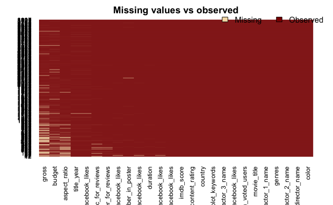

```r
library(Amelia)
missmap(mm, main = "Missing values vs observed")
```

```r
sapply(mm,function(x) sum(is.na(x))) # number of missing values for each variable
```

```
                    color             director_name    num_critic_for_reviews
                        0                         0                        39
                 duration   director_facebook_likes    actor_3_facebook_likes
                        6                        74                        13
             actor_2_name    actor_1_facebook_likes                     gross
                        0                         4                       572
                   genres              actor_1_name               movie_title
                        0                         0                         0
          num_voted_users cast_total_facebook_likes              actor_3_name
                        0                         0                         0
     facenumber_in_poster             plot_keywords      num_user_for_reviews
                       12                         0                        13
                  country            content_rating                    budget
                        0                         0                       298
               title_year    actor_2_facebook_likes                imdb_score
                       74                         7                         0
             aspect_ratio      movie_facebook_likes
                      222                         0
```

We noticed that there are many missing values for budget,aspect ratio and gross.